# GiveMeGestalt

Jakob Litsch, Dawit Asfaha, Friedrich Heitzer, Alexander Palatnik

7/17/2019

# Final Project of the Experimental Psychology Lab

## Introduction

As part of the course “Experimental Psychology Lab” at University Osnabrück offered by Prof. Dr. Michael Franke we were given the task to replicate a study as our final project. We chose the paper “Give me Gestalt! Preference for Cubist Artwork revealing High Detectability of Objects” written by Claudia Muth and several other members of the Department of General Psychology and Methodology at the University of Bamberg and published on the 21. of November, 2012. The theoretical background lies mainly in the Gestalt theory. Scientists have hypothesized that perceptual grouping processes are linked to the ‘reward system’, neural structures that induce a pleasant sensation after finishing a task. This study is the first to show empirically that in fact there is a connection between detectability of Gestalt or objects in challenging visual stimuli and a pleasing sensation. This is a highly interesting observation as it is in conflict with statements such as that viewers derive aesthetic pleasure from violations of their perceptual predictions. The goal of our replication is to find out whether our results would support the hypothesis of the original study. Furthermore, we have done research on cubism and the stimuli which were presented in the original study. Cubism can be devided into analytical and synthetic cubism. We wanted to check if and to what degree the different cubist styles as well as color affects the detectability ratings of the artworks.

## Hypotheses

[H1] Participants without expertise in cubism appreciate cubist artworks more if they can easily detect concealed objects in them. [H2] Synthetic cubism shows higher detectability than analytical cubism. [H3] Participants without expertise in cubism appreciate colorful cubist artworks more than monochrome cubist artworks.

## Participants

Twenty-nine participants volunteered in the study (15 females, 13 males, 1 unknown gender). The age range is 18-78 with an apporximate mean age of 30. The participants were tested for color vision by a short version of the ishihara vision test.

## Procedure

Participants performed the experiment at a location of their choice due to this being an online replication only. After a short explanation of what the participant should expect from the experiment and what his/her tasks are the participant starts with the Ishihara test. Our Ishihara test consists of four picture which were shown to the participant in a randomized order. If the participant failed the test, we exclude them from the analysis of the study. Additionally, we managed to exclude children, people with expertise in cubism, no english knowledge and/or neruological disorders due to the fact that we recruited the participants from our friends and family. The test is followed by the first block of pictures (60 pictures) which were to rate on liking on a scale from 1 (not much) to 7 (very). In the second block the same pictures were shown and the participants were asked to rate them again from 1 to 7 but this time on detecatibility of objects in the picture. In both blocks the pictures were presented in a randomized order. We have decided to not do test trials beforehand, due to the simplicity of the task. The cubist artworks we used were provided by the conducters of the original study.

## Analysis

In order to analyse the data we have to tidy it up. We select the columns we need for the analysis, shorten the strings for easier comparison, manually filter out the participants who failed the Ishihara test or responded too quick and restructure the dataframe in a way so that we end up with a likeability and a detectability column for later plotting. Moreover, we plot the dataset and construct a metric and a monotonic model to see if we can prove our hypothesis. Additionally, we compare the models to see which one fits best. At the end we also look at the impact of style and color on the detactability of objects.

### Load The libraries

```r
library(tidyverse)
library(brms)
```

### Read the data

```r
data <- read_csv("results_group5.csv")
data
```

```
## # A tibble: 3,720 x 24
##    submission_id QUD      RT   age comments education endTime experiment_id
##            <dbl> <lgl> <dbl> <dbl> <chr>    <chr>       <dbl>         <dbl>
##  1           705 NA     6275    21 <NA>     Graduate… 1.56e12            73
##  2           705 NA    21893    21 <NA>     Graduate… 1.56e12            73
##  3           705 NA     4306    21 <NA>     Graduate… 1.56e12            73
##  4           705 NA     4049    21 <NA>     Graduate… 1.56e12            73
##  5           705 NA     4818    21 <NA>     Graduate… 1.56e12            73
##  6           705 NA     2193    21 <NA>     Graduate… 1.56e12            73
##  7           705 NA     3387    21 <NA>     Graduate… 1.56e12            73
##  8           705 NA     3228    21 <NA>     Graduate… 1.56e12            73
##  9           705 NA     3130    21 <NA>     Graduate… 1.56e12            73
## 10           705 NA     3662    21 <NA>     Graduate… 1.56e12            73
## # … with 3,710 more rows, and 16 more variables: gender <chr>,
## #   languages <chr>, min_chars <dbl>, optionLeft <chr>, optionRight <chr>,
## #   picture <chr>, position <chr>, question <chr>, response <chr>,
## #   response_checked <lgl>, startDate <chr>, startTime <dbl>,
## #   timeSpent <dbl>, top <dbl>, trial_name <chr>, trial_number <dbl>
```

### Select and mutate important columns

```r
data <- select(data, RT, response, submission_id, trial_name, picture)

data <- mutate(data, trial_name=factor(trial_name), response=factor(response, ordered=T))

data
```

```
## # A tibble: 3,720 x 5
##       RT response submission_id trial_name picture
##    <dbl> <ord>            <dbl> <fct>      <chr>
##  1  6275 29                 705 ishihara   Ishihara/29.jpg
##  2 21893 9                  705 ishihara   Ishihara/6.jpg
##  3  4306 8                  705 ishihara   Ishihara/8.jpg
##  4  4049 18                 705 ishihara   Ishihara/18.jpg
##  5  4818 7                  705 firstblock realartsyimages/106.jpg
##  6  2193 5                  705 firstblock realartsyimages/009.jpg
##  7  3387 5                  705 firstblock realartsyimages/002.jpg
##  8  3228 6                  705 firstblock realartsyimages/086.jpg
##  9  3130 4                  705 firstblock realartsyimages/078.jpg
## 10  3662 6                  705 firstblock realartsyimages/047.jpg
## # … with 3,710 more rows
```

### Tidy up picture column

```r
data <- data.frame(lapply(data, function(x) {gsub("realartsyimages/", "", x)}))
data <- data.frame(lapply(data, function(x) {gsub(".jpg", "", x)}))
data <- data.frame(lapply(data, function(x) {gsub("Ishihara/", "", x)}))

data
```

```
##           RT response submission_id  trial_name picture
## 1       6275       29           705    ishihara      29
## 2      21893        9           705    ishihara       6
## 3       4306        8           705    ishihara       8
## 4       4049       18           705    ishihara      18
## 5       4818        7           705  firstblock     106
## 6       2193        5           705  firstblock     009
## 7       3387        5           705  firstblock     002
## 8       3228        6           705  firstblock     086
## 9       3130        4           705  firstblock     078
## 10      3662        6           705  firstblock     047
## 11      1599        7           705  firstblock     045
## 12      4770        6           705  firstblock     006
## 13      2844        5           705  firstblock     083
## 14      3992        3           705  firstblock     015
```

[output cut: 3706 more lines]

### Manually filter out our testrun, participants who failed the Ishihara Test and participants who misunderstood the task.

777, 708, 707, 875 failed the Ishihara test. The Ishihara test is considered as failed if a participant makes two or more mistakes. Answers such as “Yes, Y, Yeah” etc. were considered as mistakes. 640 was a Testrun by us. 772 clearly misunderstood the task.

```r
#777, 708, 707, 875
#640 was a Testrun by us

data <- filter(data, !(submission_id %in% c("707", "708", "777", "875","640","772")))
data <- filter(data, trial_name != "ishihara")

data
```

```
##          RT response submission_id  trial_name picture
## 1      4818        7           705  firstblock     106
## 2      2193        5           705  firstblock     009
## 3      3387        5           705  firstblock     002
## 4      3228        6           705  firstblock     086
## 5      3130        4           705  firstblock     078
## 6      3662        6           705  firstblock     047
## 7      1599        7           705  firstblock     045
## 8      4770        6           705  firstblock     006
## 9      2844        5           705  firstblock     083
## 10     3992        3           705  firstblock     015
## 11     1682        7           705  firstblock     103
## 12     1962        7           705  firstblock     072
## 13     1846        5           705  firstblock     036
## 14     6063        4           705  firstblock     014
```

[output cut: 2866 more lines]

### Restructure Dataframe to Have a likeability and a detectability column

```r
firstblock <- filter(data, trial_name=="firstblock")
secondblock <- filter(data, trial_name=="secondblock")
jointdataset <- merge(firstblock, secondblock, by = c('submission_id','picture')) %>% mutate(RT.x = as.numeric(RT.x), RT.y = as.numeric(RT.y))

jointdataset
```

```
##      submission_id picture RT.x response.x trial_name.x RT.y response.y
## 1              703     001 1047          2   firstblock 2042          2
## 2              703     002 1857          4   firstblock  225          2
## 3              703     003 1874          3   firstblock  382          2
## 4              703     004  524          5   firstblock  429          2
## 5              703     005 1248          3   firstblock  330          2
## 6              703     006  878          3   firstblock  583          2
## 7              703     007   54          3   firstblock  247          2
## 8              703     008 1611          1   firstblock 1821          1
## 9              703     009  847          4   firstblock  202          1
## 10             703     010  917          3   firstblock  170          2
## 11             703     011  823          3   firstblock  448          2
## 12             703     012  210          3   firstblock  988          3
## 13             703     013  993          5   firstblock 1337          2
## 14             703     014 1296          4   firstblock  224          2
```

[output cut: 2821 more lines]

### Filter out too fast RTs

All rows with a quicker RT than the printed value below were removed.

```r
print(mean(jointdataset$RT.x)-1.25*sd(jointdataset$RT.x))
```

```
## [1] 390.4658
```

```r
jointdataset <- filter(jointdataset, RT.x >= mean(RT.x)-1.25*sd(RT.x), RT.y >= mean(RT.x)-1.25*sd(RT.x)) %>% mutate(liking = factor(response.x, ordered = T), detectability = factor(response.y, ordered = T)) %>% select(ID = submission_id, picture, RTliking= RT.x, RTdetectability = RT.y, liking, detectability) %>% as_tibble()

jointdataset
```

```
## # A tibble: 1,076 x 6
##    ID    picture RTliking RTdetectability liking detectability
##    <fct> <fct>      <dbl>           <dbl> <ord>  <ord>
##  1 703   001         1047            2042 2      2
##  2 703   004          524             429 5      2
##  3 703   006          878             583 3      2
##  4 703   008         1611            1821 1      1
##  5 703   011          823             448 3      2
##  6 703   013          993            1337 5      2
##  7 703   036         1596             418 5      2
##  8 703   037         1117             568 3      2
##  9 703   041         1375             497 3      2
## 10 703   042         1632             648 3      2
## # … with 1,066 more rows
```

### Plotting the dataset

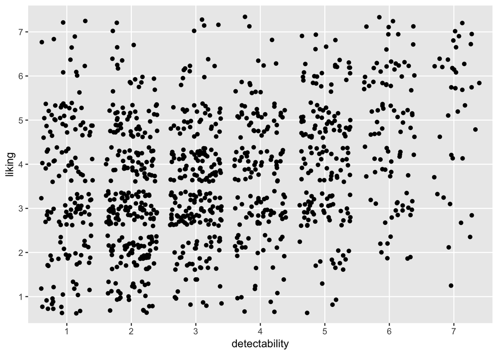

```r
ggplot(jointdataset, aes(x = detectability, y= liking)) + geom_jitter() + geom_smooth(method = "lm")
```

### Construct a monotonic model

```r
m_monotonic = brm(formula = liking ~ mo(detectability),
               data = jointdataset,
               family = cumulative("logit"))
```

### Construct a metric model

```r
m_metric = brm(formula = liking ~ as.numeric(detectability),
               data = jointdataset,
               family = cumulative("logit"))
```

## Plotting the monotnic and metric model

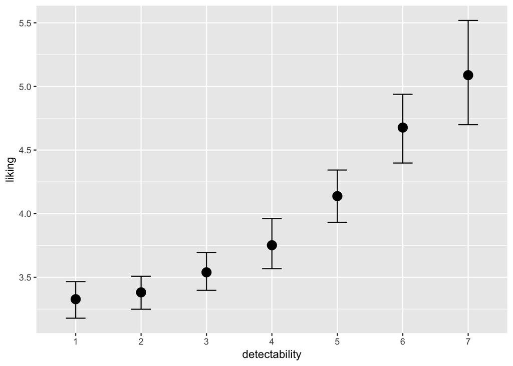

```r
marginal_effects(m_monotonic)
```

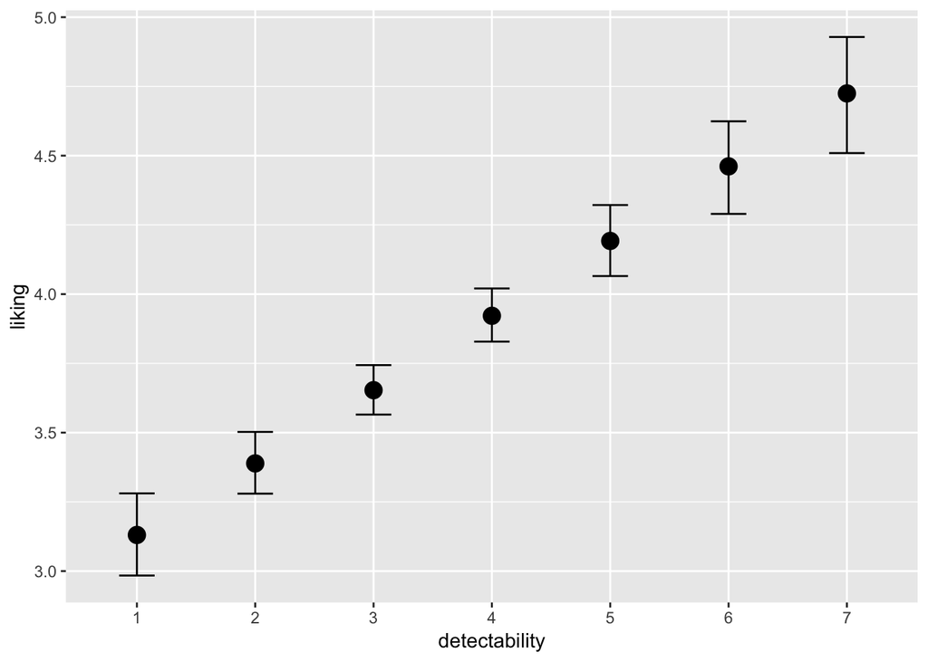

```r
marginal_effects(m_metric)
```

### Showing significant results of the two models

The results show that both models lead to significant reults supporting the hypothesis. You can see this in the table in the population-level effects tables in respectively the last row in the 95% columns. As the interval of the 95% columns does not contain zero the results show a significant positive correlation between liking and detectability.

```r
m_monotonic
```

```
##  Family: cumulative
##   Links: mu = logit; disc = identity
## Formula: liking ~ mo(detectability)
##    Data: jointdataset (Number of observations: 1076)
## Samples: 4 chains, each with iter = 2000; warmup = 1000; thin = 1;
##          total post-warmup samples = 4000
##
## Population-Level Effects:
##                 Estimate Est.Error l-95% CI u-95% CI Eff.Sample Rhat
## Intercept[1]       -2.28      0.14    -2.56    -2.00       2536 1.00
## Intercept[2]       -0.92      0.11    -1.12    -0.70       4118 1.00
## Intercept[3]        0.37      0.10     0.18     0.57       4728 1.00
## Intercept[4]        1.32      0.11     1.13     1.54       4456 1.00
## Intercept[5]        2.63      0.13     2.37     2.89       4053 1.00
## Intercept[6]        4.06      0.19     3.70     4.45       4107 1.00
## modetectability     0.38      0.05     0.28     0.49       2503 1.00
##
## Simplex Parameters:
##                     Estimate Est.Error l-95% CI u-95% CI Eff.Sample Rhat
## modetectability1[1]     0.03      0.03     0.00     0.10       4885 1.00
## modetectability1[2]     0.09      0.05     0.01     0.20       3585 1.00
## modetectability1[3]     0.12      0.07     0.01     0.27       2816 1.00
## modetectability1[4]     0.21      0.09     0.05     0.40       3629 1.00
## modetectability1[5]     0.31      0.10     0.11     0.51       3931 1.00
## modetectability1[6]     0.24      0.12     0.02     0.46       2603 1.00
##
## Samples were drawn using sampling(NUTS). For each parameter, Eff.Sample
## is a crude measure of effective sample size, and Rhat is the potential
## scale reduction factor on split chains (at convergence, Rhat = 1).
```

```r
m_metric
```

```
##  Family: cumulative
##   Links: mu = logit; disc = identity
## Formula: liking ~ as.numeric(detectability)
##    Data: jointdataset (Number of observations: 1076)
## Samples: 4 chains, each with iter = 2000; warmup = 1000; thin = 1;
##          total post-warmup samples = 4000
##
## Population-Level Effects:
##                         Estimate Est.Error l-95% CI u-95% CI Eff.Sample
## Intercept[1]               -1.68      0.16    -2.00    -1.37       3421
## Intercept[2]               -0.32      0.13    -0.58    -0.06       4456
## Intercept[3]                0.96      0.13     0.70     1.23       4574
## Intercept[4]                1.91      0.14     1.64     2.19       4369
## Intercept[5]                3.18      0.17     2.86     3.50       4312
## Intercept[6]                4.59      0.22     4.17     5.02       4487
## as.numericdetectability     0.34      0.04     0.26     0.40       4276
##                         Rhat
## Intercept[1]            1.00
## Intercept[2]            1.00
## Intercept[3]            1.00
## Intercept[4]            1.00
## Intercept[5]            1.00
## Intercept[6]            1.00
## as.numericdetectability 1.00
##
## Samples were drawn using sampling(NUTS). For each parameter, Eff.Sample
## is a crude measure of effective sample size, and Rhat is the potential
## scale reduction factor on split chains (at convergence, Rhat = 1).
```

### Comparing the 2 models

Loo() shows the better model depending on estimating points accurately while punishing complexity. The better model is the top one shown in the table “Model comparisons” and in this case the monotonic model is slightly better.

```r
loo(m_metric, m_monotonic)
```

```
## Output of model 'm_metric':
##
## Computed from 4000 by 1076 log-likelihood matrix
##
##          Estimate   SE
## elpd_loo  -1879.8 17.7
## p_loo         7.3  0.2
## looic      3759.6 35.4
## ------
## Monte Carlo SE of elpd_loo is 0.0.
##
## All Pareto k estimates are good (k < 0.5).
## See help('pareto-k-diagnostic') for details.
##
## Output of model 'm_monotonic':
##
## Computed from 4000 by 1076 log-likelihood matrix
##
##          Estimate   SE
## elpd_loo  -1873.4 18.0
## p_loo        10.7  0.4
## looic      3746.7 35.9
## ------
## Monte Carlo SE of elpd_loo is 0.1.
##
## All Pareto k estimates are good (k < 0.5).
## See help('pareto-k-diagnostic') for details.
##
## Model comparisons:
##             elpd_diff se_diff
## m_monotonic  0.0       0.0
## m_metric    -6.4       3.7
```

### Creating a dataframe for H2 and H3

style(0 = analytical, 1 = synthetic), color(0 = colored, 1 = monochrome)

```r
styledata <- read_csv("style_cub3.csv")
#styledata$picture <- seq.int(nrow(styledata))
styledata
```

```
## # A tibble: 120 x 3
##    picture style color
##    <chr>   <dbl> <dbl>
##  1 001         0     0
##  2 117         0     0
##  3 002         0     0
##  4 003         0     0
##  5 004         0     0
##  6 005         0     0
##  7 006         0     0
##  8 119         0     0
##  9 007         0     0
## 10 008         0     0
## # … with 110 more rows
```

### [H2] and [H3] analysis

As our results support the statement that liking goes hand in hand with detectability we do not check whether color affects liking but we check whether color affects detectability.

```r
imagedata <- select(jointdataset, ID, picture, liking, detectability) %>% merge(styledata, by = c('picture')) %>% mutate(style = factor(style, ordered = T), color = factor(color, ordered = T))

imagedata
```

```
##      picture  ID liking detectability style color
## 1        001 703      2             2     0     0
## 2        001 802      4             2     0     0
## 3        001 775      6             3     0     0
## 4        001 741      3             5     0     0
## 5        001 778      6             2     0     0
## 6        001 763      4             1     0     0
## 7        001 733      3             2     0     0
## 8        001 716      4             3     0     0
## 9        001 765      3             1     0     0
## 10       001 704      3             3     0     0
## 11       001 766      6             6     0     0
## 12       001 712      7             1     0     0
## 13       001 847      5             5     0     0
## 14       001 781      3             2     0     0
```

[output cut: 1062 more lines]

### Plotting

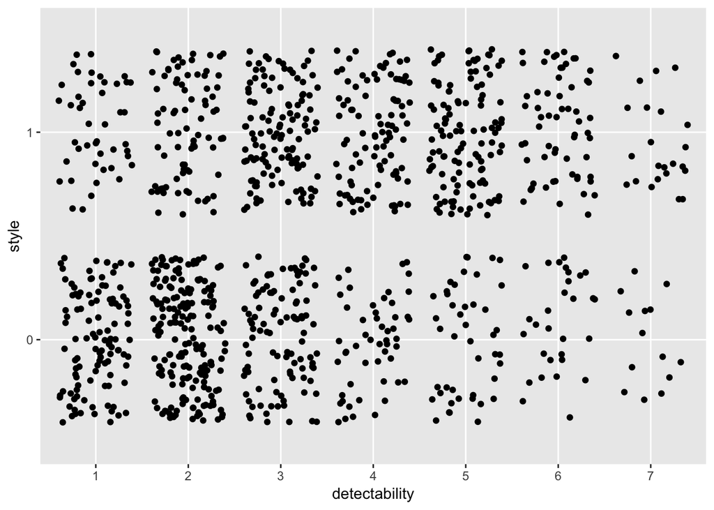

```r
ggplot(imagedata, aes(x = detectability, y = style)) + geom_jitter() + geom_smooth(method = "lm")
```

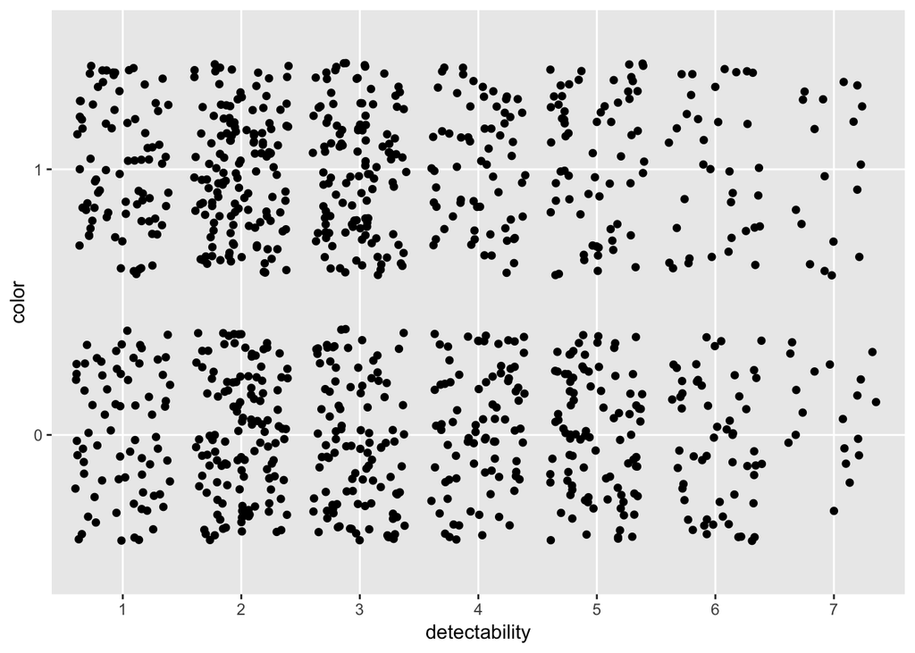

```r
ggplot(imagedata, aes(x = detectability, y = color)) + geom_jitter() + geom_smooth(method = "lm")
```

### Construct models

```r
m_metric_style = brm(formula = detectability ~ style,
               data = imagedata,
               family = cumulative("logit"))
```

```
## recompiling to avoid crashing R session
```

```r
m_metric_color = brm(formula = detectability ~ color,
               data = imagedata,
               family = cumulative("logit"))
```

```
## recompiling to avoid crashing R session
```

### Plotting metric models

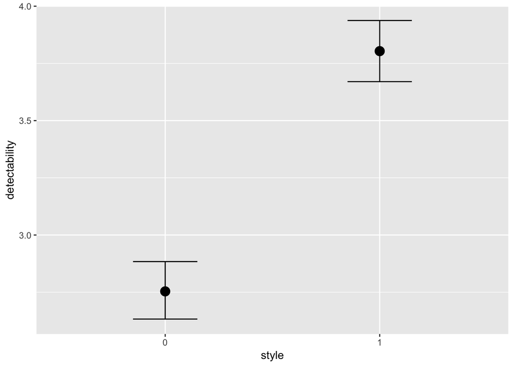

```r
marginal_effects(m_metric_style)
```

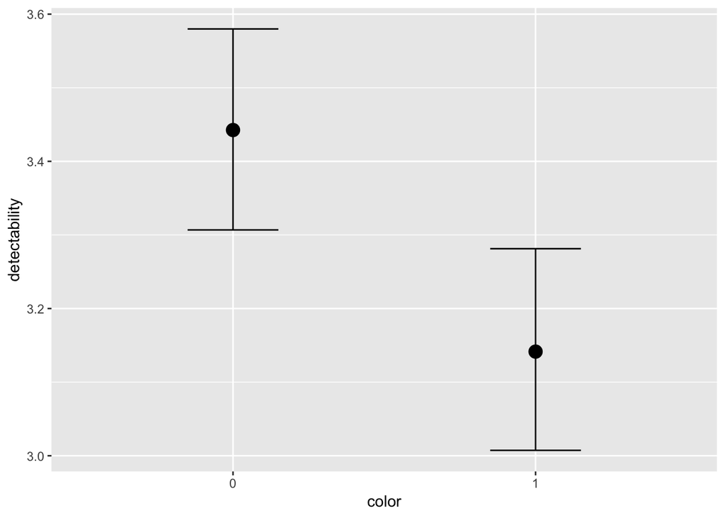

```r
marginal_effects(m_metric_color)
```

### Showing significant results of the two models

While the style seems to have a clear effect on the detectability of objects supporting [H2], the effect of color is not as strong although there is a slightly negative correlation. Yet, we can not conclude that this supports [H3] as there are not exactly the same amount of colorful and monochrome pictures considered in this model. The difference in considered trials between the colorful and monochrome pictures is approximately 30.

```r
m_metric_style
```

```
##  Family: cumulative
##   Links: mu = logit; disc = identity
## Formula: detectability ~ style
##    Data: imagedata (Number of observations: 1076)
## Samples: 4 chains, each with iter = 2000; warmup = 1000; thin = 1;
##          total post-warmup samples = 4000
##
## Population-Level Effects:
##              Estimate Est.Error l-95% CI u-95% CI Eff.Sample Rhat
## Intercept[1]    -1.92      0.09    -2.10    -1.74       2614 1.00
## Intercept[2]    -0.49      0.06    -0.62    -0.37       4452 1.00
## Intercept[3]     0.44      0.07     0.31     0.57       4737 1.00
## Intercept[4]     1.13      0.07     0.99     1.27       4436 1.00
## Intercept[5]     2.17      0.10     1.98     2.36       4823 1.00
## Intercept[6]     3.53      0.17     3.21     3.87       5385 1.00
## style.L          0.84      0.08     0.68     0.99       4790 1.00
##
## Samples were drawn using sampling(NUTS). For each parameter, Eff.Sample
## is a crude measure of effective sample size, and Rhat is the potential
## scale reduction factor on split chains (at convergence, Rhat = 1).
```

```r
m_metric_color
```

```
##  Family: cumulative
##   Links: mu = logit; disc = identity
## Formula: detectability ~ color
##    Data: imagedata (Number of observations: 1076)
## Samples: 4 chains, each with iter = 2000; warmup = 1000; thin = 1;
##          total post-warmup samples = 4000
##
## Population-Level Effects:
##              Estimate Est.Error l-95% CI u-95% CI Eff.Sample Rhat
## Intercept[1]    -1.80      0.09    -1.97    -1.63       3374 1.00
## Intercept[2]    -0.47      0.06    -0.59    -0.35       4976 1.00
## Intercept[3]     0.39      0.06     0.27     0.51       4709 1.00
## Intercept[4]     1.03      0.07     0.89     1.17       4819 1.00
## Intercept[5]     2.03      0.09     1.84     2.21       5715 1.00
## Intercept[6]     3.38      0.17     3.06     3.71       6717 1.00
## color.L         -0.23      0.08    -0.38    -0.08       6203 1.00
##
## Samples were drawn using sampling(NUTS). For each parameter, Eff.Sample
## is a crude measure of effective sample size, and Rhat is the potential
## scale reduction factor on split chains (at convergence, Rhat = 1).
```